# Evaluation of the CAZyme classifiers: dbCAN, CUPP and eCAMI

Emma E. M. Hobbs

2021 December

# 1 Introduction

The CAZyme classifiers dbCAN ([Zhange et al. 2018](https://academic.oup.com/nar/article/46/W1/W95/4996582)), CUPP ([Barrett and Lange, 2019](https://www.ncbi.nlm.nih.gov/pmc/articles/PMC6489277/)) and eCAMI ([Xu et al. 2019](https://academic.oup.com/bioinformatics/article/36/7/2068/5651014)) use different methods to predict if a protein is a CAZyme or non-CAZyme, and predict the CAZy family annotations for predicted CAZymes. These classifiers have not been independently evaluated against a high quality benchmark test set.

This notebook layouts out the independent evaluation of dbCAN, CUPP and eCAMI against a high quality benchmark test set. The tools were evaluated upon their ability to differentiate between CAZymes and non-CAZymes, and their performance of predicting the CAZy family annotations of predicted CAZymes.

dbCAN incorporates the three protein function classifiers HMMER ([Potter et al. 2018](https://pubmed.ncbi.nlm.nih.gov/29905871/)), Hotpep ([Busk et al. 2017](https://pubmed.ncbi.nlm.nih.gov/28403817/)), and DIAMOND ([Buchfink et al. 2015](https://www.nature.com/articles/nmeth.3176)). In order to comprehensively evaluate the preformance of dbCAN, the predictions from HMMER, Hotpep and DIAMOND were evaluated independently of each other, and the consensus prediction (a prediction which at least two of the tools agree upon) was defined as the dbCAN result.

# 2 Test sets

70 test sets were parsed by every CAZyme classifier. Each test set was generated using a different genome, and each test set contained 200 unique protein sequences retrieved from the same genome. 100 of the protein sequences were randomly selected known CAZyme (identified as proteins catagloued in CAZy) and the 100 non-CAZyme (proteins not catalogued in CAZy) with the highest sequence similarity (rated by bit-score-ratio) to the 100 selected CAZymes. Choosing the 100 non-CAZymes with the highest sequence similarity was devised to increase increase the probability of causing confusion and evaluate and thus provide a estimation of the minimum expected perforamnce per classifier. An equal number of CAZymes to non-CAZymes was selected to prevent over representation of one population over the other.

In order for a genomic assembly to be used for the creation of a test set, the assembly had to meet of all the following criteria:

- Contains at least 100 CAZymes
- Contains at least 100 non-CAZymes
- Has an ‘Assembly level’ of ‘Complete Genome’ in the NCBI Assembly database
- Protein records are still present in NCBI
- Not listed as an ‘Anomalous assembly’ in the NCBI Assembly database

The genomic assemblies were also chosen from a range of taxonomies to provide as informative image of the performance of the classifiers over a range of datasets that users may wish to analyse.

Table 2.1 contains the genomic assemblies used to create the test sets for the evaluation. In total 70 assemblies were chose, including 39 bacterial and 31 eukaryota genomes.

Table 2.1: Genomic assembiles selected for creation of high quality benchmarking test sets for the evaluation of the CAZyme classifiers dbCAN, CUPP and eCAMI

| Phylogeny | Strain | NCBI Taxonomy ID | GenBank Assembly Accession | Number of CAZymes in CAZy |
| --- | --- | --- | --- | --- |
| Oomycetes | Dictyoglomus turgidum DSM 6724 | 515635 | GCA_000021645.1 | 101 |
| Fungi Ascomycetes | Aspergillus flavus NRRL 3357 | 227321 | GCA_009017415.1 | 441 |
|  | Aspergillus chevalieri M1 | 182096 | GCA_016861735.1 | 521 |
|  | Metarhizium brunneum 4556 | 500148 | GCA_013426205.1 | 394 |
|  | Peltaster fructicola (ascomycetes) LNHT1506 | 403677 | GCA_001592805.2 | 267 |
|  | Penicillium digitatum (ascomycetes) PdW03 | 36651 | GCA_016767815.1 | 318 |
|  | Micromonas commoda (green algae) RCC299 | 296587 | GCA_000090985.2 | 148 |
|  | Yarrowia lipolytica DSM 3286 | 4652 | GCA_014490615.1 | 133 |
|  | Botrytis cinerea B05.10 | 332648 | GCA_000143535.4 | 341 |
|  | Eremothecium gossypii ATCC 10895 | 284811 | GCA_000091025.4 | 108 |
|  | Kluyveromyces lactis CBS 2105 | 28985 | GCA_007993695.1 | 242 |
|  | Kluyveromyces lactis NRRL Y-1140 | 284590 | GCA_000002515.1 | 118 |
|  | Kluyveromyces marxianus CBS4857 | 4911 | GCA_001854445.2 | 123 |
|  | Pyricularia oryzae | 318829 | GCA_004346965.1 | 550 |
|  | Sugiyamaella lignohabitans CBS 10342 | 796027 | GCA_001640025.2 | 150 |
|  | Fusarium culmorum Class2-1B | 5516 | GCA_016952355.1 | 486 |
|  | Fusarium oxysporum Fo47 | 660027 | GCA_013085055.1 | 719 |
|  | Fusarium pseudograminearum Class2-1C | 101028 | GCA_016952305.1 | 485 |
|  | Cordyceps militaris ATCC 34164 | 73501 | GCA_008080495.1 | 319 |
|  | Clavispora lusitaniae P5 | 36911 | GCA_009498115.1 | 135 |
| Yeast | Brettanomyces bruxellenesis UCD 2041 | 5007 | GCA_011074885.2 | 140 |
|  | Pichia kudriavzevii CBS573 | 4909 | GCA_003054445.1 | 137 |
|  | Brettanomyces nanus CBS 1945 | 13502 | GCA_011074865.2 | 140 |
|  | Metschnikowia aff. pulcherrima (budding yeasts) APC 1.2 | 2163413 | GCA_004217705.1 | 136 |
|  | Zygosaccharomyces parabailii ATCC 60483 | 1365886 | GCA_001984395.2 | 220 |
|  | [Candida] glabrata BG2 | 5478 | GCA_014217725.1 | 146 |
|  | [Candida] auris B11220 | 498019 | GCA_003013715.2 | 131 |
|  | [Candida] auris B11245 | 498019 | GCA_008275145.1 | 131 |
|  | Candida dubliniensis CD36 | 573826 | GCA_000026945.1 | 140 |
| Eukrayote | Ostreococcus lucimarinus CCE9901 | 436017 | GCA_000092065.1 | 115 |
|  | Chloropicon primus CCMP1205 | 1764295 | GCA_007859695.1 | 221 |
| Gram Positive Bacteria | Hungateiclostridium thermocellum ATCC 27405 | 203119 | GCA_000015865.1 | 144 |
|  | Hungateiclostridium clariflavum DSM 19732 | 720554 | GCA_000237085.1 | 147 |
|  | Alicyclobacillus sp. SO9 | 2665646 | GCA_016406125.1 | 113 |
|  | Bacillus altitudinis 11-1-1 | 293387 | GCA_013283915.1 | 100 |
|  | Bacillus amyloliquefaciens MOH1-5b | 1039 | GCA_014792065.1 | 102 |
|  | Bacillus amyloliquefaciens KHG19 | 1292358 | GCA_000835145.1 | 101 |
|  | Dickeya chrysanthemi Ech1591 | 561229 | GCA_000023565.1 | 108 |
|  | Dickeya dianthicola ME23 | 1940567 | GCA_003403135.1 | 116 |
|  | Enterococcus faecium isolate 2014-VREF-268 | 1352 | GCA_002025045.1 | 104 |
|  | Enterococcus casseliflavus EC291 | 37734 | GCA_009707345.1 | 145 |
|  | Clostridium saccharoperbutylacetonicum N1-504 | 36745 | GCA_002003305.1 | 214 |
|  | Clostridium beijerinckii NCIMB 14988 | 1520 | GCA_000833105.2 | 193 |
|  | Ruminiclostridium cellulolyticum H10 | 394503 | GCA_000022065.1 | 144 |
|  | Streptomyces bingchenggensis BCW-1 | 749414 | GCA_000092385.1 | 387 |
|  | Streptomyces sporoclivatus NBRC 100767 | 284038 | GCA_009936315.1 | 361 |
|  | Schleiferilactobacillus harbinensis NSMJ42 | 304207 | GCA_008694105.1 | 153 |
|  | Streptacidiphilus sp. P02-A3a | 2704468 | GCA_014084105.1 | 288 |
|  | Streptosporangium roseum DSM 43021 | 479432 | GCA_000024865.1 | 254 |
|  | Nocardia arthritidis AUSMDU00012717 | 228602 | GCA_011801145.1 | 189 |
|  | Mycobacterium sp. JS623 | 212767 | GCA_000328565.1 | 136 |
| Gram Negative Bacteria | Actinobacillus equuli NCTC9435 | 718 | GCA_900638075.1 | 117 |
|  | Azospirillum brasilense Sp 7 | 192 | GCA_001315015.1 | 161 |
|  | Caulobacter segnis ATCC 21756 | 509190 | GCA_000092285.1 | 116 |
|  | Cellvibrio japonicus Ueda107 | 498211 | GCA_000019225.1 | 222 |
|  | Enterobacter asburiae CAV1043 | 61645 | GCA_003940765.1 | 205 |
|  | Escherichia coli 142 | 562 | GCA_005221905.1 | 100 |
|  | Escherichia coli 144 | 562 | GCA_005221585.1 | 282 |
|  | Klebsiella aerogenes 035 | 548 | GCA_011604725.1 | 110 |
|  | Klebsiella michiganensis BD177 | 1134687 | GCA_010093005.1 | 157 |
|  | Klebsiella oxytoca KONIH4 | 571 | GCA_002906395.1 | 162 |
|  | Pseudobacter ginsenosidimutans Gsoil 221 | 661488 | GCA_007970185.1 | 233 |
|  | Pseudomonas cerasi | 1583341 | GCA_900074915.1 | 101 |
|  | Salmonella enterica subsp. arizonae NCTC10047 | 59203 | GCA_900635675.1 | 146 |
|  | Serratia marcescens 11/2010 | 615 | GCA_013426155.1 | 105 |
|  | Serratia marcescens SM39 | 1334564 | GCA_000828775.1 | 101 |
|  | Verrucomicrobia bacterium HZ-65 | 2026799 | GCA_002310495.1 | 282 |
|  | Verrucomicrobia bacterium IMCC26134 | 1637999 | GCA_000972765.1 | 181 |
|  | Xanthomonas citri subsp. citri A306 | 1308541 | GCA_000816885.1 | 171 |
|  | Xanthomonas citri subsp. citri Aw12879 | 1137651 | GCA_000349225.1 | 170 |

```
## Mean percentage of genome incorporated in the CAZome across all test sets:  3.140472 ± SD 1.174488
```

```
## Mean percentage of CAZomes incorporated in the test set across all genomes:  64.37203 ± SD 25.54491
```

The distribution of the coverage of the CAZyme by the respective test sets is presented in figure 2.1

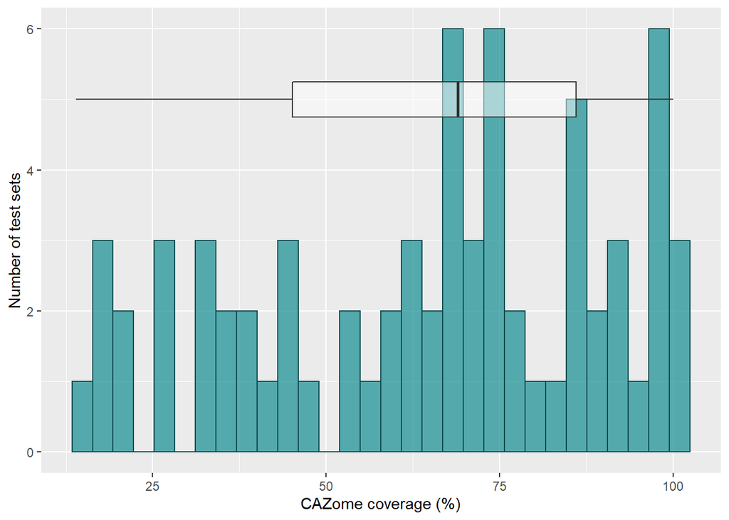

Figure 2.1: Histogram of CAZome coverage of the test sets for each respective source genomic assembly, overlayed by a box and whisker plot of the percentage of the CAZome incorproated in the test set.

# 3 Evaluation of binary CAZyme/non-CAZyme classification

The assignment of CAZy family annotations to proteins that meet specific criteria by a CAZyme classifier identifies the protein as a CAZyme. If no CAZy family annotations are assigned to a protein by a CAZyme classifier, the tool has identified the protein as a non-CAZyme. This notebook evaluates the performance of the CAZyme classifiers dbCAN (which incorporates HMMER, Hotpep and DIAMOND), CUPP and eCAMI for this binary CAZyme/non-CAZyme classification.

## 3.1 Summary statistics

For every classifier-test set pair, the specificity, sensitivity, prevision, F1-score and accuracy were calculated.

The mean of each statistical parameter was calculated for each classifier across all tests, to represent the overall performance of each CAZyme classifier.

These results are presented in table 3.1.

Table 3.1: Overall performance of CAZyme classifiers differentiation between CAZymes and non-CAZymes

| Classifier | Mean Specificity | Specificity Standard Deviation | Mean Sensitivity | Sensitivity Standard Deviation | Mean Precision | Precision Standard Deviation | Mean F1-score | F1-score Standard Deviation | Mean Accuracy | Accuracy Standard Deviation |
| --- | --- | --- | --- | --- | --- | --- | --- | --- | --- | --- |
| dbCAN | 0.9869 | 0.0245 | 0.9087 | 0.1123 | 0.9866 | 0.0241 | 0.9412 | 0.0796 | 0.9478 | 0.0564 |
| HMMER | 0.9901 | 0.0163 | 0.8831 | 0.0835 | 0.9893 | 0.0174 | 0.9305 | 0.0613 | 0.9366 | 0.0422 |
| Hotpep | 0.9840 | 0.0257 | 0.8189 | 0.1327 | 0.9815 | 0.0287 | 0.8862 | 0.0917 | 0.9014 | 0.0666 |
| DIAMOND | 0.9844 | 0.0263 | 0.9261 | 0.1298 | 0.9847 | 0.0251 | 0.9481 | 0.0907 | 0.9553 | 0.0641 |
| CUPP | 0.9917 | 0.0156 | 0.8570 | 0.0825 | 0.9908 | 0.0172 | 0.9167 | 0.0531 | 0.9244 | 0.0417 |
| eCAMI | 0.9836 | 0.0257 | 0.8610 | 0.1328 | 0.9826 | 0.0254 | 0.9112 | 0.0868 | 0.9223 | 0.0647 |

## 3.2 Specificity

Specificity is the proportion of known negatives (known non-CAZymes) which are correctly classified as negatives (non-CAZymes).

Figure 3.1 is a graphical representation of the results calculated in table 3.1.

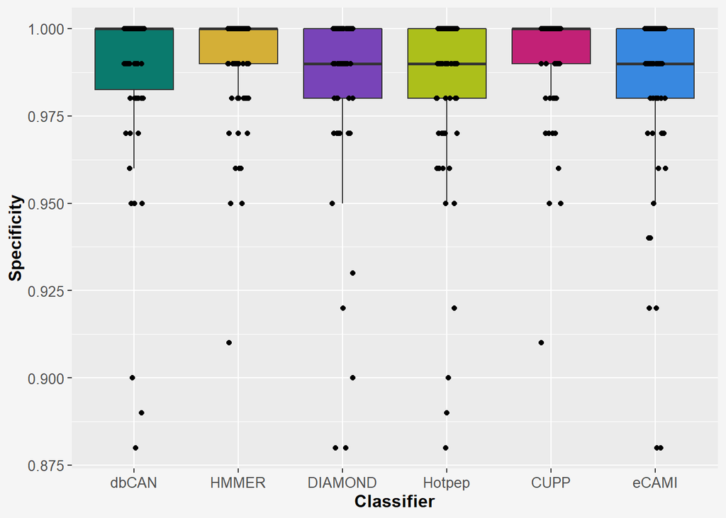

Figure 3.1: One-dimensional scatter plot of specificity scores of CAZyme and non-CAZyme predictions per test set, overlaying box plot of standard deviation.

## 3.3 Sensitivity

Sensitivity (also known as recall) is the proportion of known positives (CAZymes) that are correctly identified as positives (CAZymes).

Figure 3.2 graphically represents of the results calculated in table 3.1.

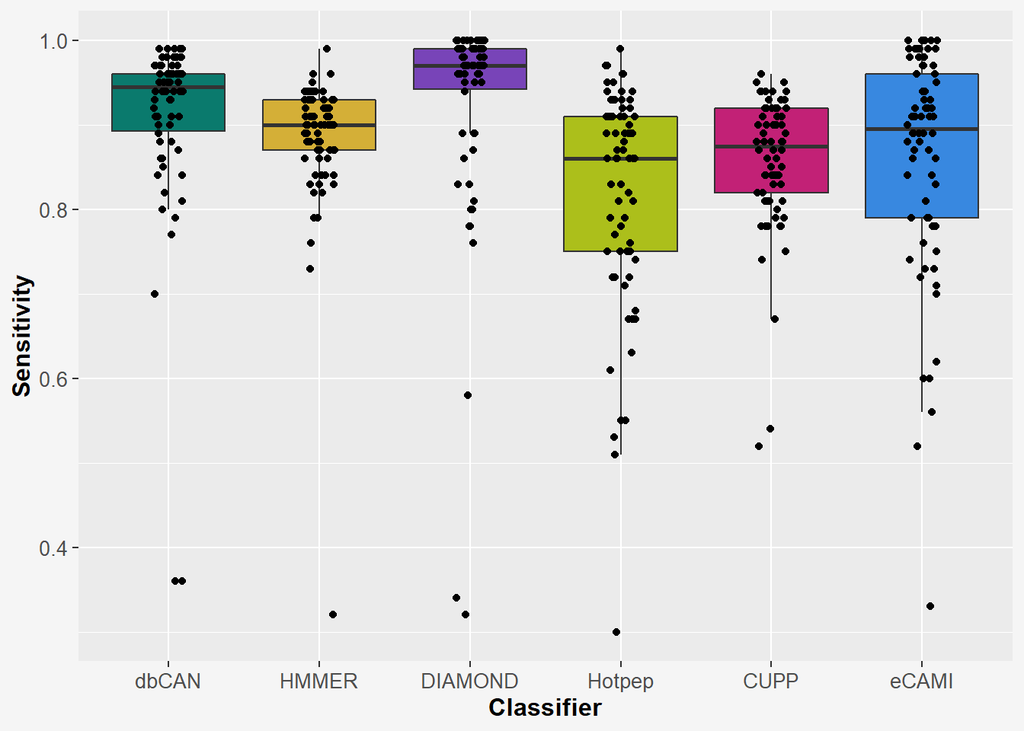

Figure 3.2: One-dimensional scatter plot of recall (sensitivity) scores of CAZyme and non-CAZyme predictions per test set, overlaying box plot of standard deviation.

## 3.4 Precision

Precision is the proportion of positive predictions by the classifiers that are correct.

In this case, precision represents the fraction of CAZyme predictions by the classifiers that are correct, specifically the proportion of predicted CAZymes that are known CAZymes.

Figure 3.3 is a visual representation of the results calculated in table 3.1.

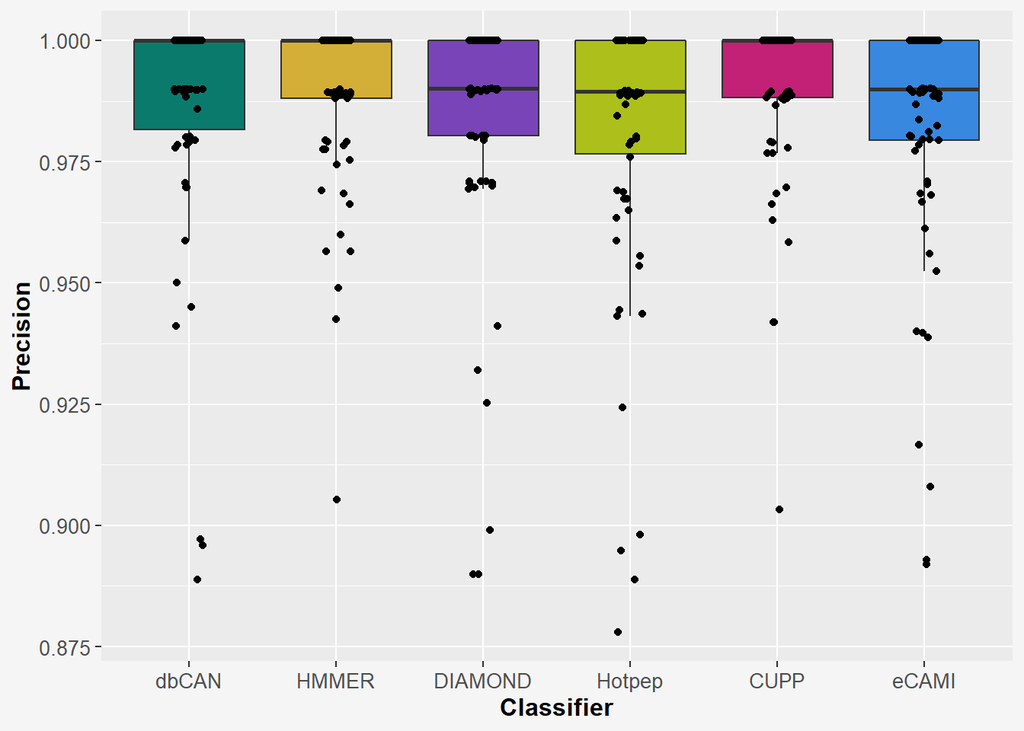

Figure 3.3: One-dimensional scatter plot of precision scores of CAZyme and non-CAZyme predictions per test set, overlaying box plot of standard deviation.

## 3.5 F1-score

The F1-score is a harmonic (or weighted) average of recall and precision and provides an idea of the overall performance of the tool, 0 being the lowest and 1 being the best performance. Figure 3.4 shows the F1-score from each test set, for each classifier.

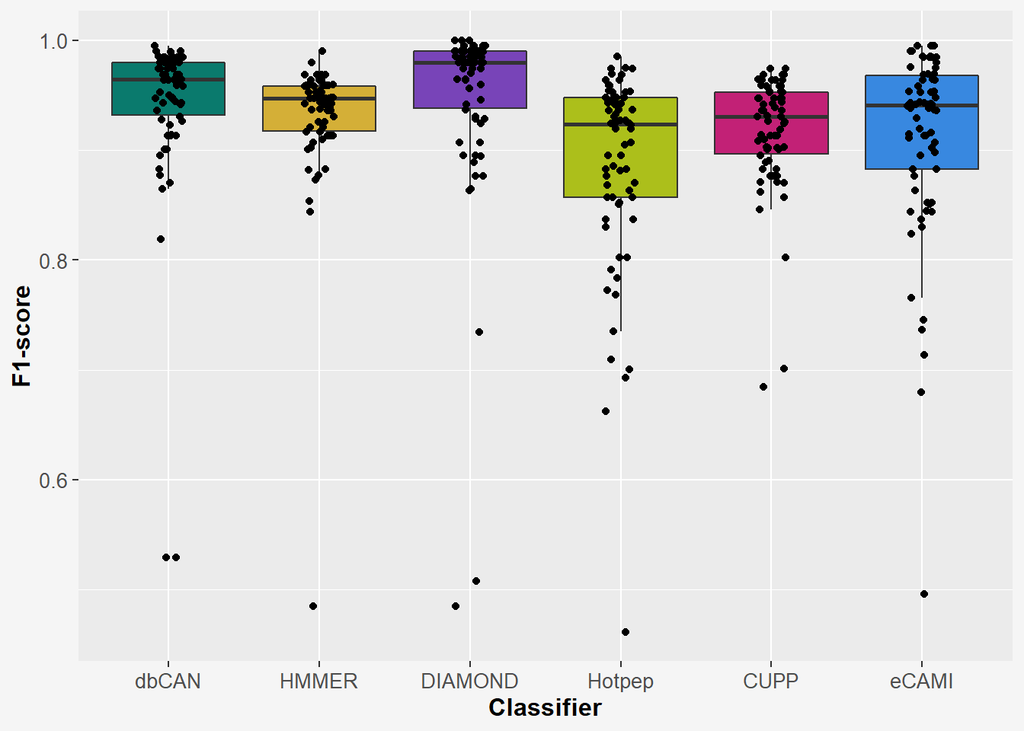

## 3.6 Accuracy

Accuracy (calculated using (TP + TN) / (TP + TN + FP + FN) ) provides an idea of the overall performance of the classifiers as a measure of the degree to which their CAZyme/non-CAZyme predictions conforms to the correct result. Figure 3.5 plots the accuracy score for each test set per CAZyme classifier.

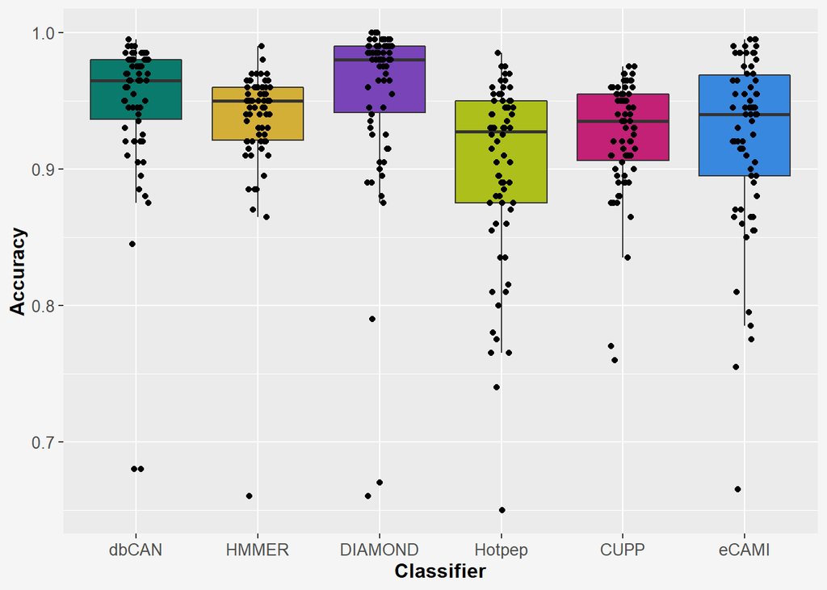

## 3.7 Expected Range of Accruacy

The statistics evaluated above provide an idea of the general performance of the tools, but they do not provide an idea of the expect range of performance. Specifically, the data does not provide a clear image of the best and worse performance a user can expect when using these tools.

To compare the expected typical range in accuracies for each classifier, 6 test sets (identified by the source genomic assemblies) were selected at random. The CAZyme/non-CAZyme predictions for each classifier, for each test set, were bootstrap resampled 100 times each, and for each bootstrap sample the accuracy calculated. The accuracies of the bootstrap samples for each classifier were plotted on stacked histograms, shown in figure 3.6.

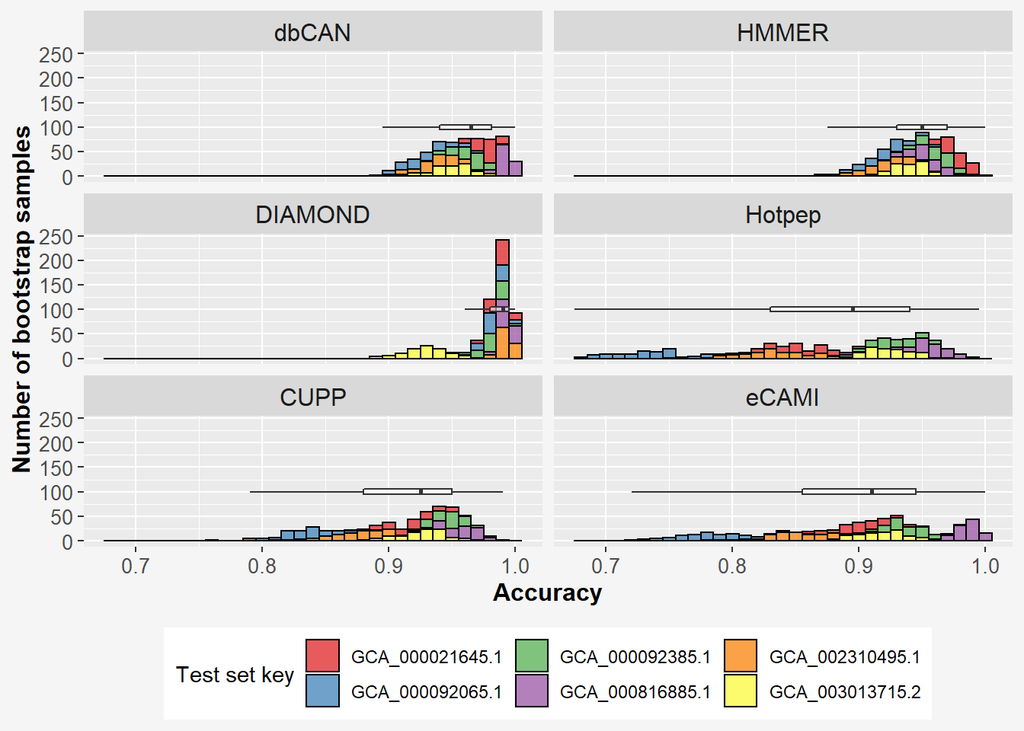

## 3.8 Investigation of Non-CAZymes classified as CAZymes (False positives)

Few of the known non-CAZymes were classified as CAZymes by the CAZyme classifiers. The cause of the non-CAZymes being classified as CAZymes may be because of a very high sequence similarity between the non-CAZyme and known CAZymes, and/or CAZy incorrectly classifying the non-CAZyme as a CAZyme and not a CAZyme. The latter case maybe true if all 6 classifiers classify the non-CAZyme as a CAZyme.

## 3.9 Conclusions on the Binary CAZyme/non-CAZyme Prediction Performance

Overall, all tools show a low probability of producing false positives (misclassifying a non-CAZyme as a CAZyme), and few of the positive predictions are false positives. Therefore, we can be confident in that the CAZyme predictions made by each of these tools are most likely (typically 90-100%) correct. However, all the classifiers demonstrated a consistent behaviour to not identify all CAZymes within a CAZome. Therefore, we can be confident in the CAZyme predictions, but should not presume all non-CAZyme predictions are correct; these classifiers are unlikely to identify the complete CAZome although a near-complete CAZome will be accuracetly identified.

# 4 Evaluation of CAZy Class classification performance

CAZy groups CAZymes into CAZy families by sequence similarity, and CAZy families are grouped into one of 6 functional classes. The CAZyme classifiers predict the CAZy family annotations of predicted CAZymes, but it is of interest to see what the level of performance of the classiferis is at the CAZy class level. Specifically, a classifier may struggle to predict the correct CAZy class for a CAZyme but consistently predict the correct CAZy class. Therefore, the aim of this part of the evaluation is to evaluate the performance of the classifiers to predict the correct CAZy class of predict CAZymes.

## 4.1 General trends in CAZy class classification performance

Below is a table summary all statistical parameters calculated in order to evaluate the performance of the CAZy class classification for each prediction tool across all CAZy classes.

Table 4.1: Overall performance of CAZyme classifiers CAZy class classification performance

| Classifier | Mean Specificity | Specificity Standard Deviation | Mean Sensitivity | Sensitivity Standard Deviation | Mean Precision | Precision Standard Deviation | Mean F1-score | F1-score Standard Deviation | Mean Accuracy | Accuracy Standard Deviation |
| --- | --- | --- | --- | --- | --- | --- | --- | --- | --- | --- |
| dbCAN | 0.9962 | 0.0121 | 0.8928 | 0.1721 | 0.9626 | 0.1298 | 0.9170 | 0.1460 | 0.9755 | 0.0429 |
| HMMER | 0.9966 | 0.0103 | 0.8270 | 0.2407 | 0.9612 | 0.1388 | 0.8675 | 0.2013 | 0.9686 | 0.0392 |
| Hotpep | 0.9749 | 0.0471 | 0.8317 | 0.2120 | 0.8576 | 0.2495 | 0.8207 | 0.2116 | 0.9421 | 0.0673 |
| DIAMOND | 0.9956 | 0.0130 | 0.9078 | 0.1960 | 0.9578 | 0.1526 | 0.9213 | 0.1725 | 0.9816 | 0.0426 |
| CUPP | 0.9975 | 0.0097 | 0.7118 | 0.3888 | 0.7695 | 0.4098 | 0.7343 | 0.3937 | 0.9554 | 0.0635 |
| eCAMI | 0.9852 | 0.0324 | 0.8362 | 0.2157 | 0.8966 | 0.2066 | 0.8487 | 0.1950 | 0.9590 | 0.0536 |

Figure 4.1 presents a proportional area plot representing the F-1 score for each CAZyme classifier per test set. Each square is sized proportional to the number of test sets containing a CAZy family from the given CAZy class and CAZy families predicted by the classifiers to be in the test set.

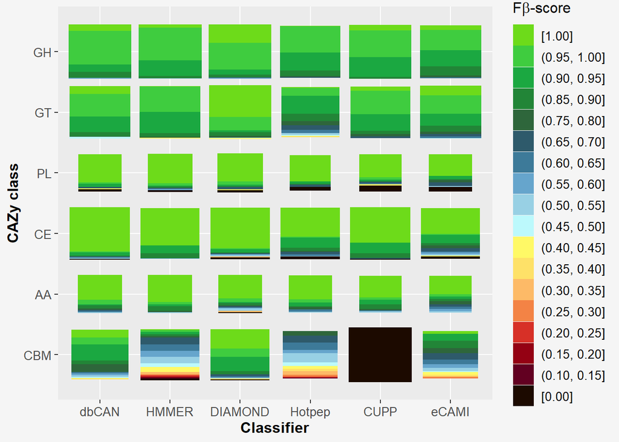

Figure 4.1: F1-score of CAZy class classification per CAZyme classifier for each test set. Squares are proportionally sized by the number of test sets containing or predicted to containing each CAZy class. The squares are shaded to represent the distribution of F1-scores of CAZy class classification performance for the respective CAZy class and classifier per test set.

Table 4.2 lists the number of test sets evaluated during the evaluation of CAZy class classification per CAZy class, for each CAZyme classifier.

| Classifier | GH | GT | PL | CE | AA | CBM |
| --- | --- | --- | --- | --- | --- | --- |
| dbCAN | 70 | 70 | 38 | 67 | 37 | 70 |
| HMMER | 70 | 70 | 38 | 67 | 37 | 70 |
| DIAMOND | 70 | 70 | 38 | 67 | 37 | 70 |
| Hotpep | 70 | 70 | 38 | 67 | 37 | 70 |
| CUPP | 70 | 70 | 38 | 67 | 37 | 70 |
| eCAMI | 70 | 70 | 39 | 67 | 37 | 70 |

The sensitivity of each CAZyme classifier can be plotted against the specificity for each CAZy class, however plotting all CAZy classes in a single plot produces an overly cramped plot, unless very few test sets were used, as shown in figure 4.2.

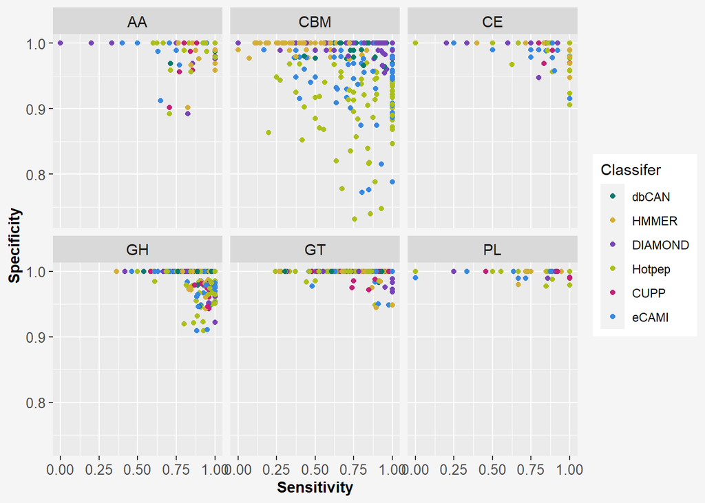

Figure 4.2: Scatter plot of specificity against sensitiity for CAZy class classification per test set for each CAZyme classifier

## 4.2 Performance per CAZy class

Below the prediction sensitivity is plotted against the specificity for each classifier, and a separate plot is generated for each CAZy class.

The scatter plots of sensitivity against specificity overlay a coloured contour to highlight the distribution of the points. When too many points have the same value a contour cannot be generated. In order to plot a contour noise is added to the data. The original data is used to plot the scatter plot and the data with added noise is used to plot the contour.

The percentage of the data points which need noise to be added to them in order to generate a contour varies from data set to data set. To change the percentage of the data points with noise added to them, change the third value of call to the function `plot.class.sens.vs.spec()`, which is used to generate the plots. The third value is the percentage of data points to add noise to, written in decimal form.

#### 4.2.0.1 CAZy class classification for GH

Figure 4.3 plots the specificity against sensitivity for GH CAZy class members per test set for each CAZyme classifier.

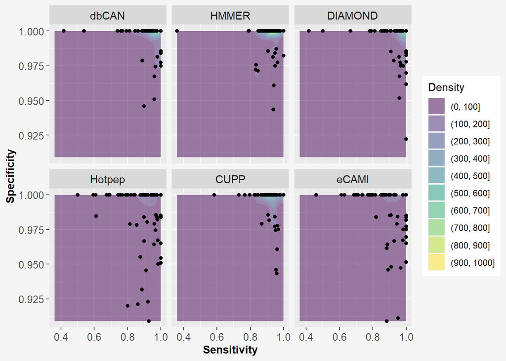

Figure 4.3: Scatter plot of specificty against sensitivity for GH CAZy class classification. Each point represents the specificity and sensitivity for each test set.

#### 4.2.0.2 CAZy class classification for GT

Figure 4.4 plots the specificity against sensitivity for GT CAZy class members per test set for each CAZyme classifier.

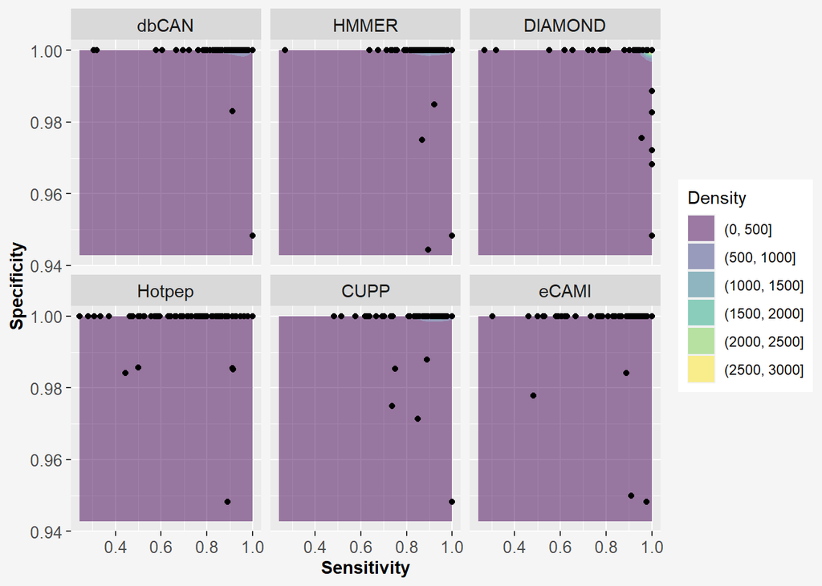

Figure 4.4: Scatter plot of specificty against sensitivity for GT CAZy class classification. Each point represents the specificity and sensitivity for each test set.

#### 4.2.0.3 CAZy class classification for PL

Figure 4.5 plots the specificity against sensitivity for PL CAZy class members per test set for each CAZyme classifier.

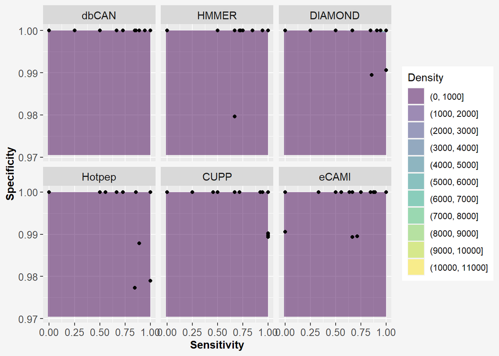

Figure 4.5: Scatter plot of specificty against sensitivity for PL CAZy class classification. Each point represents the specificity and sensitivity for each test set.

#### 4.2.0.4 CAZy class classification for CE

Figure 4.6 plots the specificity against sensitivity for CE CAZy class members per test set for each CAZyme classifier.

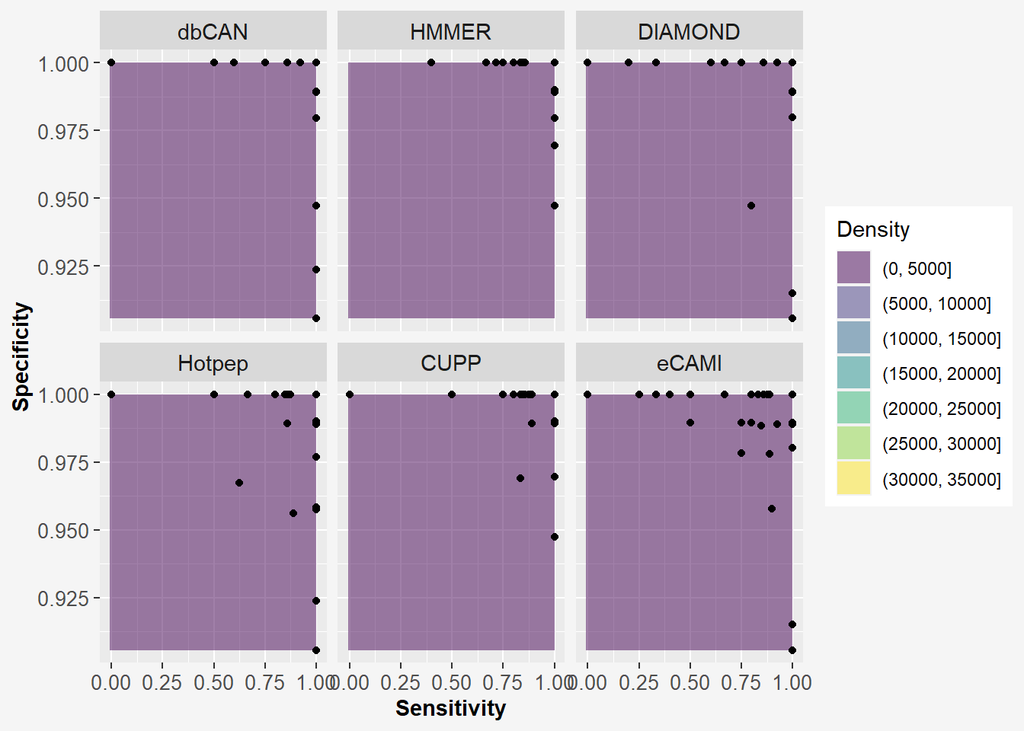

Figure 4.6: Scatter plot of specificty against sensitivity for CE CAZy class classification. Each point represents the specificity and sensitivity for each test set.

#### 4.2.0.5 CAZy class classification for AA

Figure 4.7 plots the specificity against sensitivity for AA CAZy class members per test set for each CAZyme classifier.

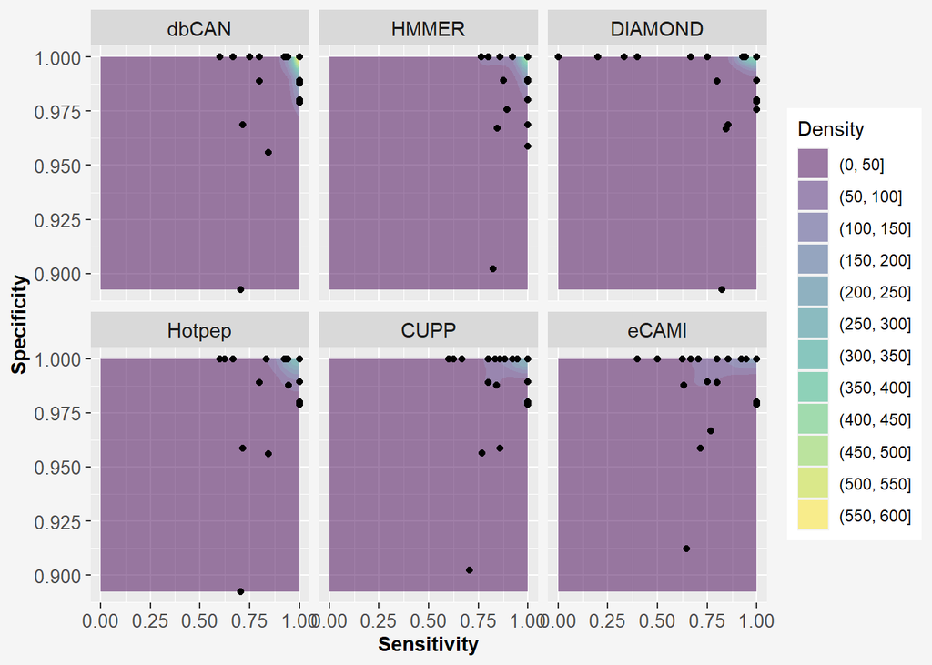

Figure 4.7: Scatter plot of specificty against sensitivity for AA CAZy class classification. Each point represents the specificity and sensitivity for each test set.

#### 4.2.0.6 CAZy class classification for CBM

Figure 4.8 plots the specificity against sensitivity for CBM CAZy class members per test set for each CAZyme classifier. Note, CUPP does not predict CBM annotations.

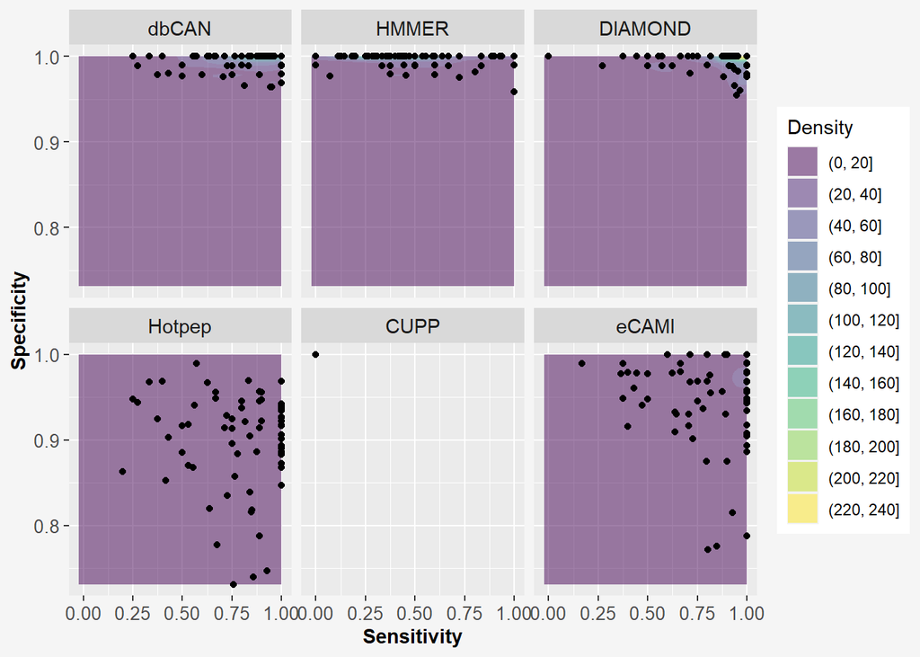

Figure 4.8: Scatter plot of specificty against sensitivity for CBM CAZy class classification. Each point represents the specificity and sensitivity for each test set.

## 4.3 Rand Index and Adjusted Rand Index of CAZy Class Prediction

A single CAZyme can be included in multiple CAZy classes leading to the multilabel classification of CAZymes. To address this and evaluate the multilabel classification of CAZy classes the Rand Index (RI) and Adjusted Rand Index (ARI) were calculated.

Table 4.3: Adjusted Rand Index of CAZyme classifier classification of CAZy class annotations

| Prediction_tool | Mean | Standard Deviation |
| --- | --- | --- |
| dbCAN | 0.9398 | 0.2359 |
| HMMER | 0.9268 | 0.2537 |
| DIAMOND | 0.9545 | 0.2079 |
| Hotpep | 0.8706 | 0.3212 |
| CUPP | 0.9007 | 0.2852 |
| eCAMI | 0.9060 | 0.2836 |

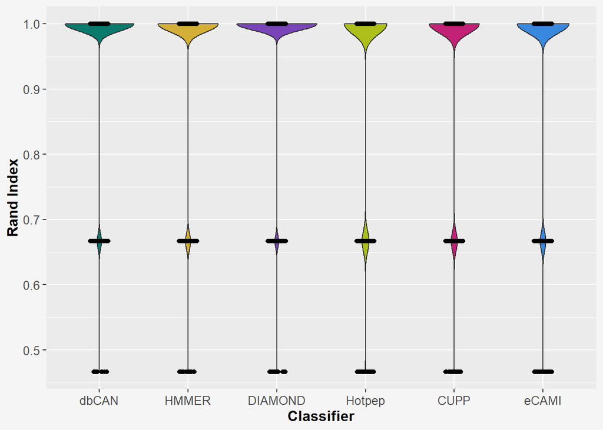

Figure 4.9: Violin plot of Rand Index (RI) of performance of the CAZyme classifiers to predict the multilabel classification of CAZy classes.

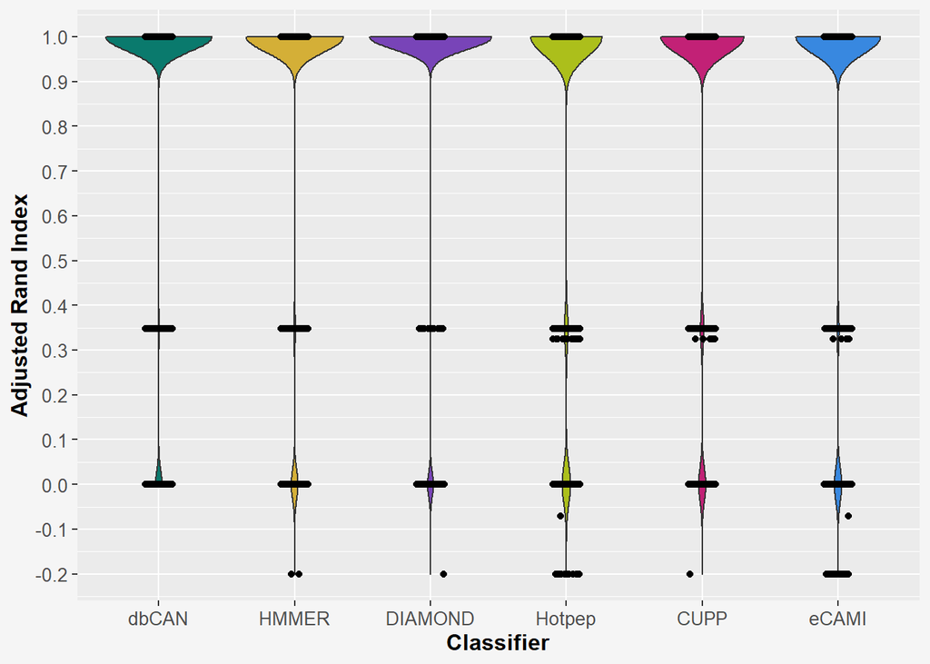

Figure 4.10: Violin plot of Adjusted Rand Index (ARI) of performance of the CAZyme classifiers to predict the multilabel classification of CAZy classes.

# 5 Evaluation CAZy family classification performance

The following section evaluates the performance of the CAZyme classifiers to predict CAZy family classifications.

**Note:** Owing to the sample size (number of proteins) per CAZy family in each test set being small, proteins were pooled from all test sets and CAZy family classification performance was evaluated against this protein pool, rather than per test set. Additionally, true negative non-CAZyme classifications were excluded from the evaluation of CAZy family classification.

## 5.1 General trends in performance across all CAZy families

Table 5.1 presents a summary of the overall CAZy family classification performance for all CAZy families across all test sets, per CAZyme classifier.

Table 5.1: Overall performance of CAZyme classifiers CAZy family classification performance across all CAZy families

| Classifier | Mean Specificity | Specificity Standard Deviation | Mean Sensitivity | Sensitivity Standard Deviation | Mean Precision | Precision Standard Deviation | Mean F1-score | F1-score Standard Deviation | Mean Accuracy | Accuracy Standard Deviation |
| --- | --- | --- | --- | --- | --- | --- | --- | --- | --- | --- |
| dbCAN | 0.9999 | 3e-04 | 0.8874 | 0.2417 | 0.9309 | 0.2275 | 0.8997 | 0.2349 | 0.9995 | 0.0014 |
| HMMER | 0.9999 | 3e-04 | 0.8703 | 0.2814 | 0.8861 | 0.2791 | 0.8640 | 0.2781 | 0.9994 | 0.0022 |
| Hotpep | 0.9994 | 2e-03 | 0.7621 | 0.3347 | 0.7661 | 0.3771 | 0.7305 | 0.3504 | 0.9987 | 0.0034 |
| DIAMOND | 0.9999 | 3e-04 | 0.8927 | 0.2386 | 0.9268 | 0.2257 | 0.9025 | 0.2323 | 0.9997 | 0.0008 |
| CUPP | 1.0000 | 2e-04 | 0.6582 | 0.4360 | 0.7048 | 0.4458 | 0.6723 | 0.4354 | 0.9992 | 0.0023 |
| eCAMI | 0.9997 | 9e-04 | 0.7356 | 0.3412 | 0.7791 | 0.3671 | 0.7372 | 0.3437 | 0.9992 | 0.0016 |

The evaluate the overall performance of each classifier, for each CAZy family, the F1-score was calculated for every family. Families were grouped by their parent CAZy class and the distribution of the F1-scores is shown in figure 5.1.

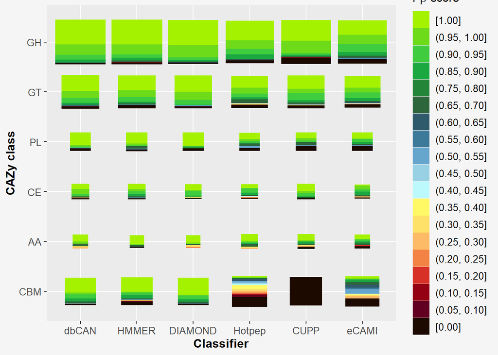

Figure 5.1: F1-score of CAZy family classification per CAZyme classifier, separated by CAZy class. Proteins were pooled from all test sets, and CAZy family classification evaluated against this protein pool. Squares are proportionally sized by the number CAZy families included or predicted by the classifier to be included in the protein tool, for each CAZy class per classifier.The squares are shaded to represent the distribution of F1-scores for each CAZy family for the respective parent CAZy class.

Table 5.2 presents the number of CAZy families included across all test sets per CAZy class, for each CAZyme classifier, and which were used to draw the proporitonal areas for each class in figure5.1.

Table 5.2: Number of CAZy families included in the evaluation of CAZy class classification per CAZy class, for each classifier

| Classifier | GH | GT | PL | CE | AA | CBM |
| --- | --- | --- | --- | --- | --- | --- |
| dbCAN | 124 | 70 | 22 | 16 | 14 | 50 |
| HMMER | 126 | 72 | 22 | 16 | 14 | 51 |
| DIAMOND | 124 | 70 | 22 | 16 | 14 | 50 |
| Hotpep | 125 | 70 | 22 | 16 | 14 | 65 |
| CUPP | 124 | 70 | 22 | 16 | 14 | 50 |
| eCAMI | 124 | 70 | 22 | 16 | 14 | 61 |

## 5.2 Performance per CAZy family

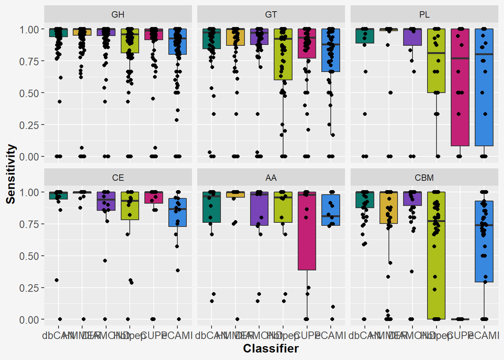

Figure 5.2: Scatter plot of overlaying a one-dimensional box-and-whisker plot of sensitivity for each CAZy family for each CAZyme classifier. Each CAZy family is represented as a single point on the plot.

To evaluate the performance of predicting each CAZy family independently of all other CAZy families, the sensitivity and specificity for each CAZy family, for each CAZyme classifier was plotted against each other as a scatter plot. For better resolution we can group the CAZy families by their parent CAzy classes, and compare the performances of the tools CAZy class, by CAZy class. Owing to the minimal variation in specificity scores, specificity was plotted as the percentage specificity log10.

### 5.2.1 Glycoside Hydrolases

Figure 5.3 shows the plotting of sensitivity against log10 specificity for each Glycoside Hydrolase CAZy family.

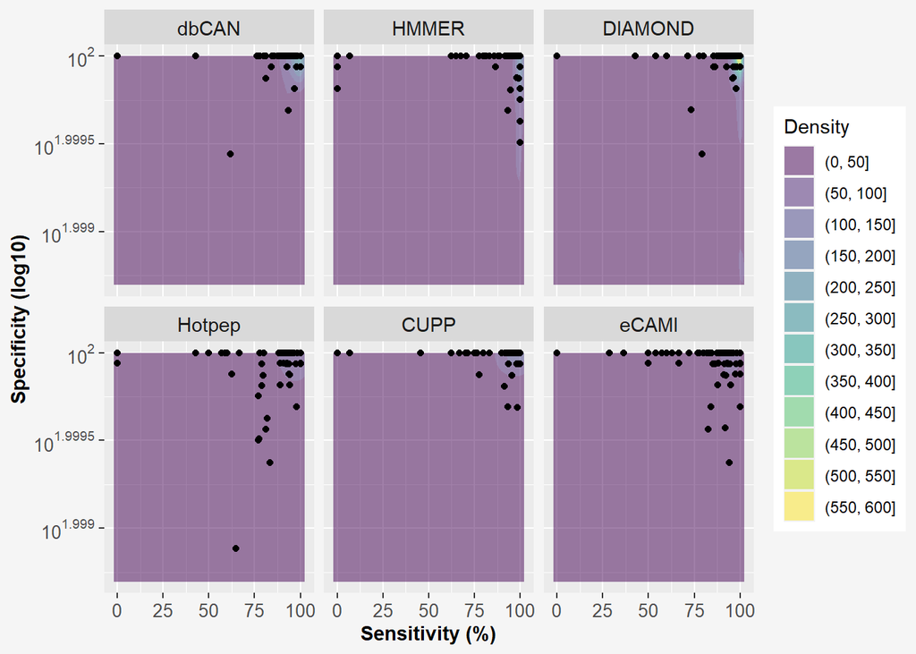

Figure 5.3: Scatter plot of recall (sensitivity) against specificity for predicting each CAZy family for each CAZyme classifier in the CAZy class Glycoside Hydrolases. Each GH CAZy family is represented as a single point on the plot.

### 5.2.2 Glycosyltransferases

Figure 5.4 shows the plotting of sensitivity against log10 specificity for each Glycosyltransferases CAZy family.

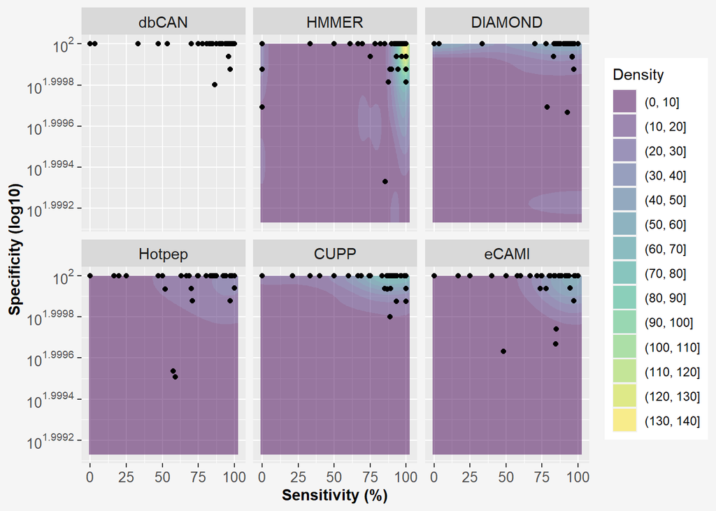

Figure 5.4: Scatter plot of recall (sensitivity) against specificity for predicting each CAZy family for each CAZyme classifier in the CAZy class Glycosyltransferases. Each GT CAZy family is represented as a single point on the plot.

### 5.2.3 Polysaccharide Lyases

Figure 5.5 shows the plotting of sensitivity against log10 specificity for each Polysaccharide Lyases CAZy family.

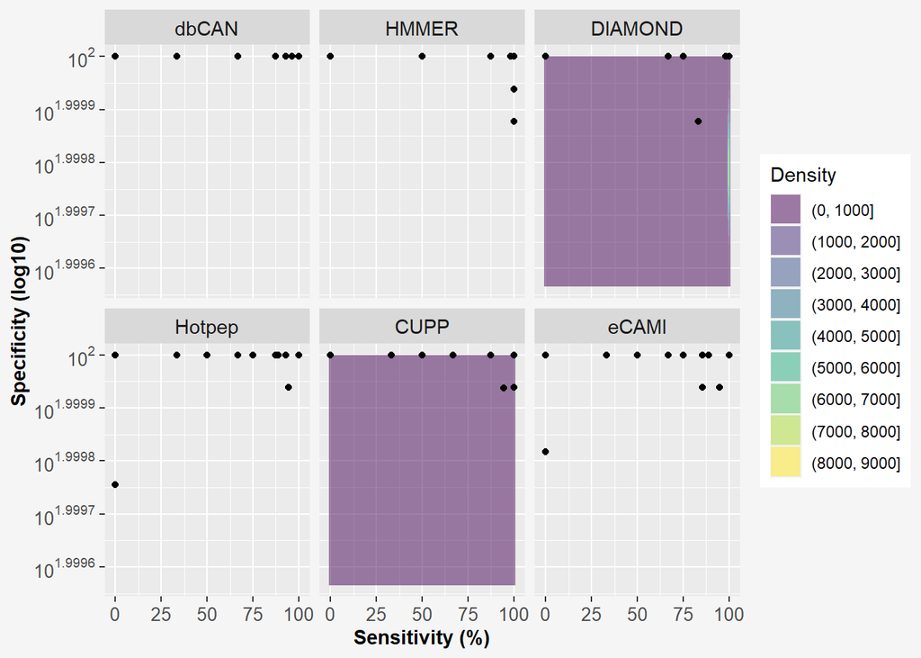

Figure 5.5: Scatter plot of recall (sensitivity) against specificity for predicting each CAZy family for each CAZyme classifier in the CAZy class Polysaccharide Lyases. Each PL CAZy family is represented as a single point on the plot.

### 5.2.4 Carbohydrate Esterases

Figure 5.6 shows the plotting of sensitivity against log10 specificity for each Carbohydrate Esterases CAZy family.

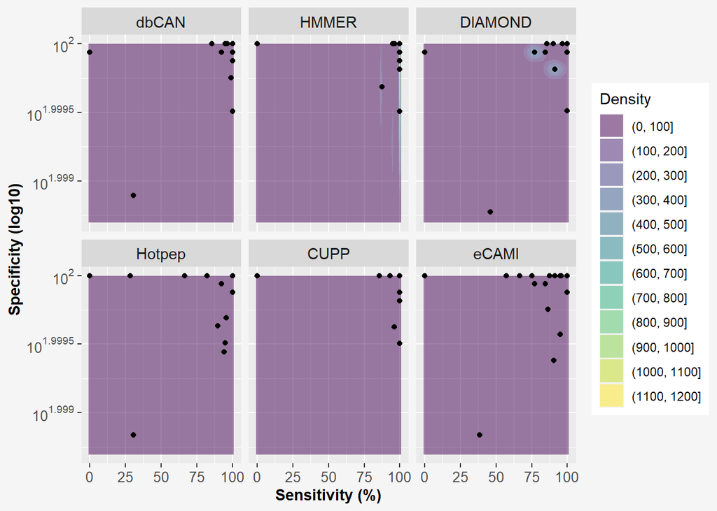

Figure 5.6: Scatter plot of recall (sensitivity) against specificity for predicting each CAZy family for each CAZyme classifier in the CAZy class Carbohydrate Esterases. Each CE CAZy family is represented as a single point on the plot.

### 5.2.5 Auxillary Activities

Figure 5.7 shows the plotting of sensitivity against log10 specificity for each Auxillary Activities CAZy family.

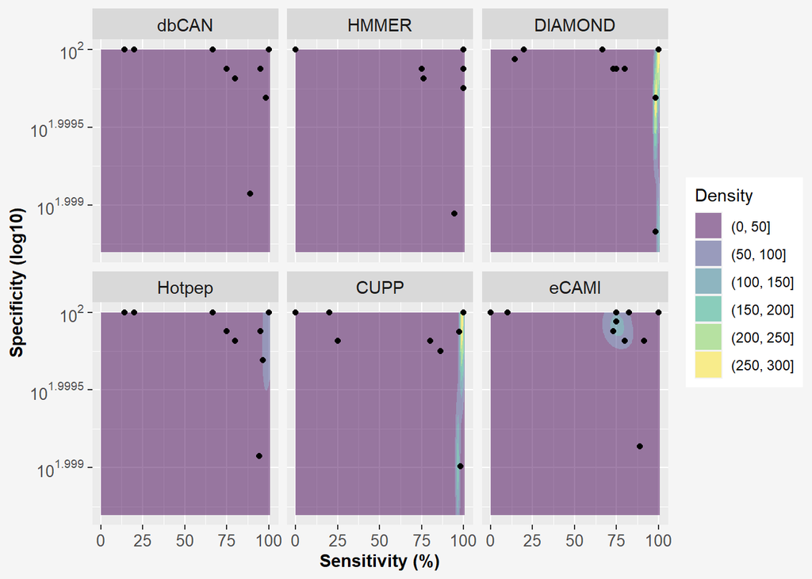

Figure 5.7: Scatter plot of recall (sensitivity) against specificity for predicting each CAZy family for each CAZyme classifier in the CAZy class Auxillary Activities. Each AA CAZy family is represented as a single point on the plot.

### 5.2.6 Carbohydate Binding Modules

Figure 5.8 shows the plotting of sensitivity against log10 specificity for each Carbohydrate Binding Module CAZy family.

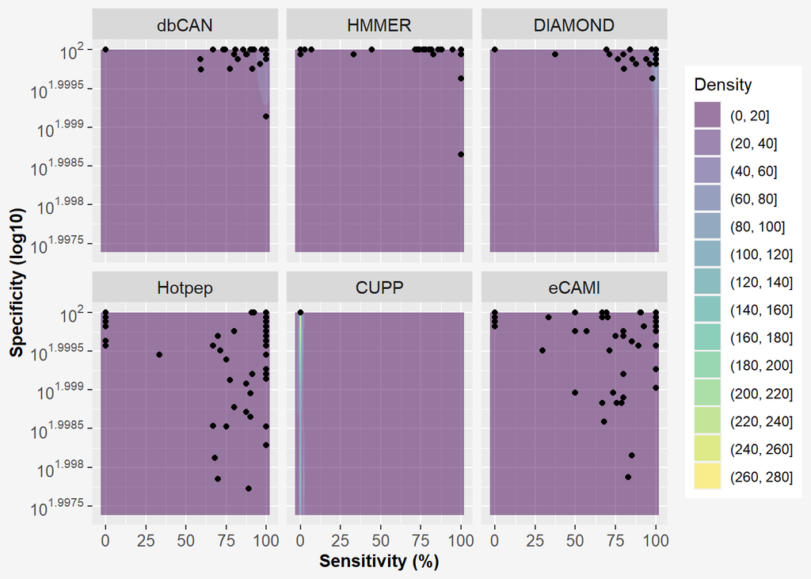

Figure 5.8: Scatter plot of recall (sensitivity) against specificity for predicting each CAZy family for each CAZyme classifier in the CAZy class Carbohydrate Binding Modules. Each CBM CAZy family is represented as a single point on the plot.

## 5.3 Consistently poor performing CAZy families

To identify if there were any CAZy families which were consistently more difficult to accuracy classify, we pulled out the CAZy families with which at least three classifiers produced a sensitivity score of less than 0.75.

### 5.3.1 GH difficult to classify families

Figure 5.9 presents the GH CAZy families for which at least two classifiers produced a sensitivity score of less than 0.75. The achieved sensitivity score is presented as well as the number of proteins in the CAZy family present in CAZy (the family ‘Population’) and the number of family members included across all test sets (the ‘Sample’ size).

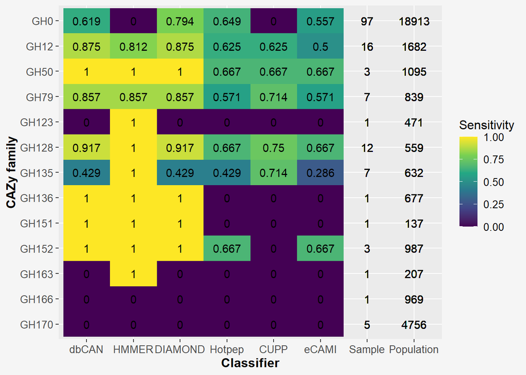

Figure 5.9: Sensitivity scores of GH CAZy families for which at least three classifiers produced scored a sensitivity of less than 0.75. The number of proteins in each CAZy family in CAZy (Population) is listed, as well as the number of CAZy family members included across all test sets (Sample (size)).

### 5.3.2 GT diffcult to classify families

Figure 5.10 presents the GT CAZy families for which at least two classifiers produced a sensitivity score of less than 0.75. The achieved sensitivity score is presented as well as the number of proteins in the CAZy family present in CAZy (the family ‘Population’) and the number of family members included across all test sets (the ‘Sample’ size).

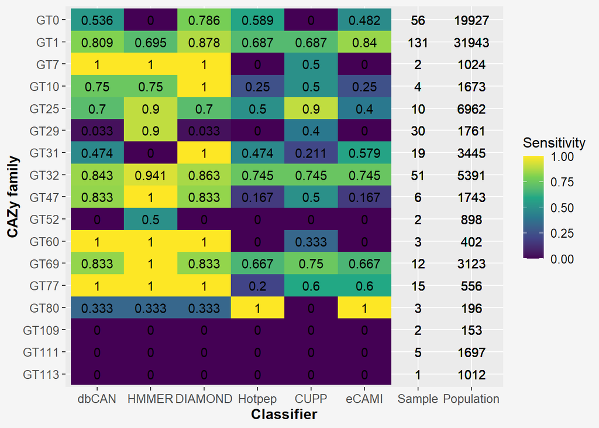

Figure 5.10: Sensitivity scores of GT CAZy families for which at least three classifiers produced scored a sensitivity of less than 0.75. The number of proteins in each CAZy family in CAZy (Population) is listed, as well as the number of CAZy family members included across all test sets (Sample (size)).

### 5.3.3 PL diffcult to classify families

Figure 5.11 presents the PL CAZy families for which at least two classifiers produced a sensitivity score of less than 0.75. The achieved sensitivity score is presented as well as the number of proteins in the CAZy family present in CAZy (the family ‘Population’) and the number of family members included across all test sets (the ‘Sample’ size).

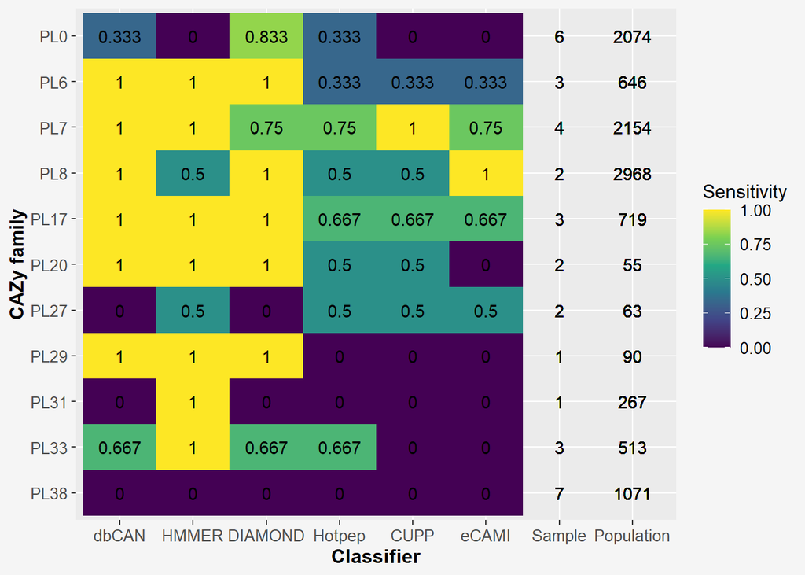

Figure 5.11: Sensitivity scores of PL CAZy families for which at least three classifiers produced scored a sensitivity of less than 0.75. The number of proteins in each CAZy family in CAZy (Population) is listed, as well as the number of CAZy family members included across all test sets (Sample (size)).

### 5.3.4 CE diffcult to classify families

Figure 5.12 presents the CE CAZy families for which at least two classifiers produced a sensitivity score of less than 0.75. The achieved sensitivity score is presented as well as the number of proteins in the CAZy family present in CAZy (the family ‘Population’) and the number of family members included across all test sets (the ‘Sample’ size).

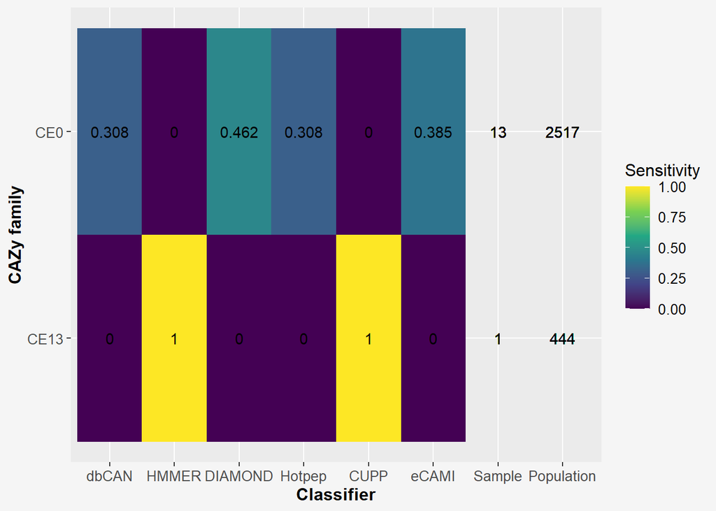

Figure 5.12: Sensitivity scores of CE CAZy families for which at least three classifiers produced scored a sensitivity of less than 0.75. The number of proteins in each CAZy family in CAZy (Population) is listed, as well as the number of CAZy family members included across all test sets (Sample (size)).

### 5.3.5 AA diffcult to classify families

Figure 5.13 presents the AA CAZy families for which at least two classifiers produced a sensitivity score of less than 0.75. The achieved sensitivity score is presented as well as the number of proteins in the CAZy family present in CAZy (the family ‘Population’) and the number of family members included across all test sets (the ‘Sample’ size).

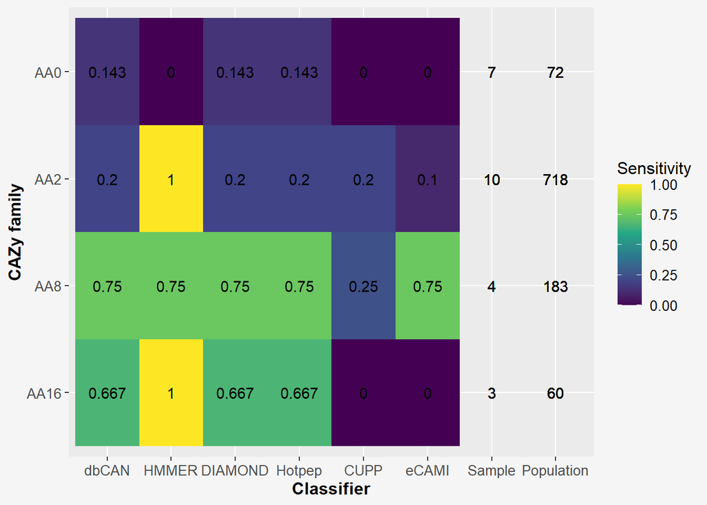

Figure 5.13: Sensitivity scores of AA CAZy families for which at least three classifiers produced scored a sensitivity of less than 0.75. The number of proteins in each CAZy family in CAZy (Population) is listed, as well as the number of CAZy family members included across all test sets (Sample (size)).

### 5.3.6 CBM diffcult to classify families

Figure 5.14 presents the CBM CAZy families for which at least two classifiers produced a sensitivity score of less than 0.75. The achieved sensitivity score is presented as well as the number of proteins in the CAZy family present in CAZy (the family ‘Population’) and the number of family members included across all test sets (the ‘Sample’ size).

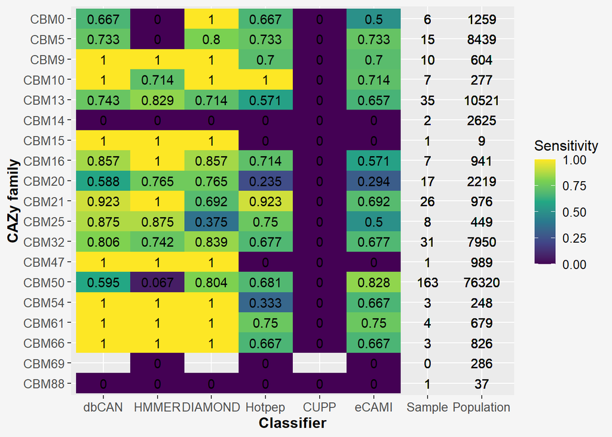

Figure 5.14: Sensitivity scores of CBM CAZy families for which at least three classifiers produced scored a sensitivity of less than 0.75. The number of proteins in each CAZy family in CAZy (Population) is listed, as well as the number of CAZy family members included across all test sets (Sample (size)).